# How BMI Affects Insurance Charge to Patient

Sean Schilk

9/14/25

# 1 Introduction

In this assignment, we are fitting a simple linear regression (SLR) by selecting a numerical explanatory variable from the data set using the least square approach and then constructing 95% bootstrap confidence intervals for the regression coefficients.

# 2 Data Set and Practical Questions

I’m using a data set provided by Mosap Abdel-Ghany on Kaggle called “Medical Insurance Cost Dataset”. The data was collected from a collection of 1338 individuals from medical insurance records.

The primary practical question is to see how the variables in the data set or derived variables from the data set affect insurance cost.

## 2.1 Data Description

The variables names in the data set and their variable type are the following:

- age (numeric)
- sex (character)
- bmi (numeric) - a measure of body fat based on height and weigh
- children (numeric) - Number of children covered by health insurance
- smoker (character) - Smoking status of the beneficiary
- region (character)- Residential region in the US
- charges (numeric) - Medical insurance cost billed to the beneficiary

# 3 Exploratory Data Analysis

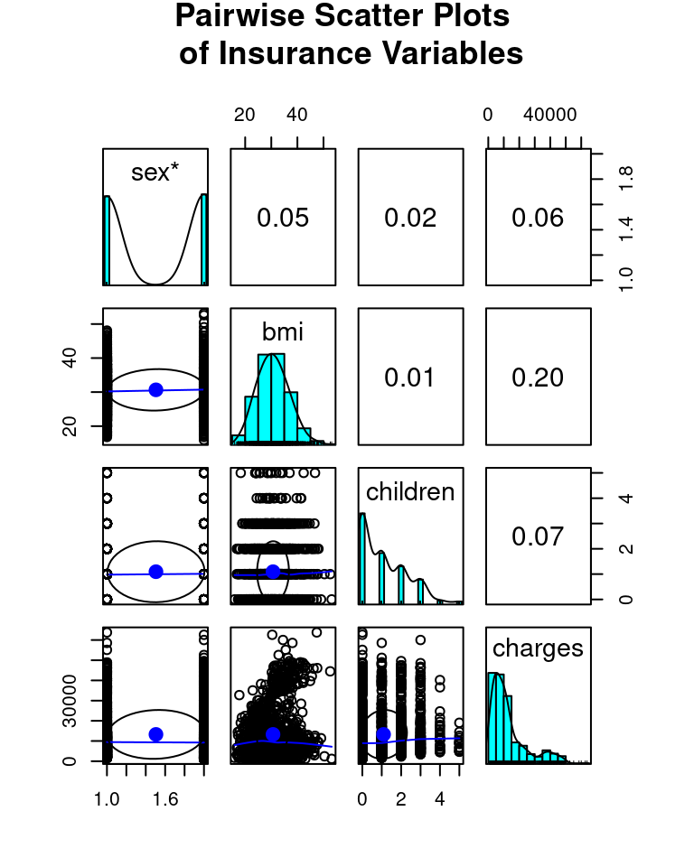

```r
# Read in dataset
library(readr)
insurance <- read_csv("https://raw.githubusercontent.com/sschilk/MySTA321/refs/heads/main/insurance.csv", show_col_types = FALSE)



pairs.panels(insurance[, -c(1,5,6)], pch=21,
             main="Pairwise Scatter Plots \n of Insurance Variables",
              cex.main = 1.1,
             ) #to show color grouping
```

```r
#\n helps with truncating titles
```

Bmi had the strongest positive linear relationship to Charges. The rest of the variables had weak positive relationships with Charges.

There is no non-linear pattern. However, if there was, you would be able to perform a transformation, notably a Box-Cox transformation.

I would choose to transform the response, Charges, as it is skewed to the right. One of the basic assumptions of a linear regression model is constant variance, meaning we cant have skewness.

# 4 Parametric SLR

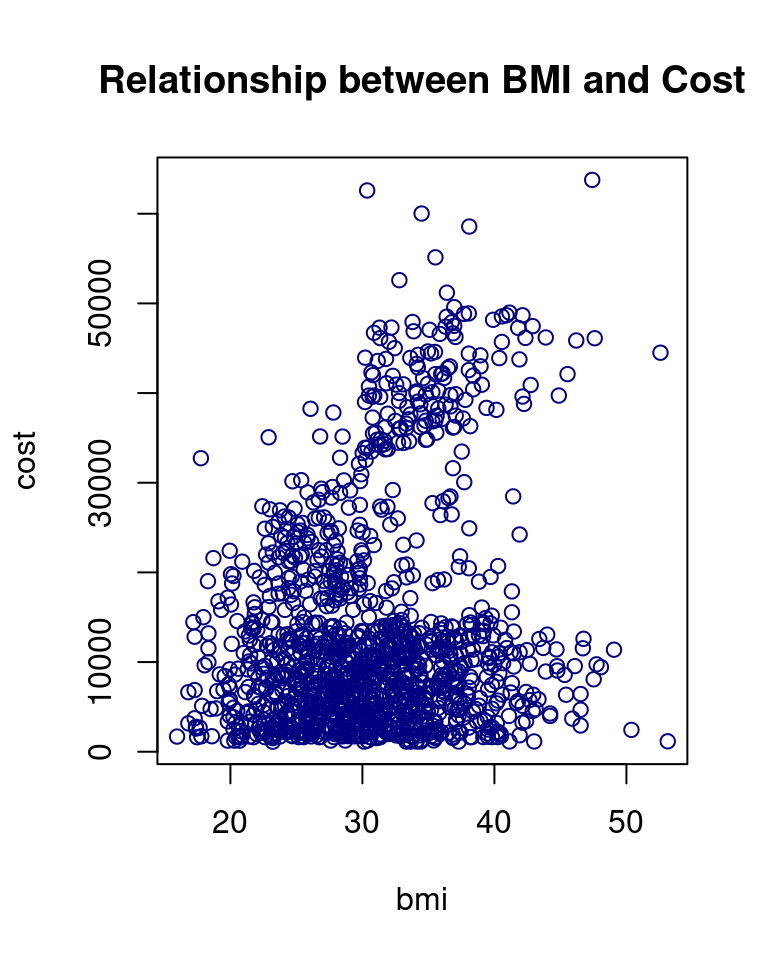

```r
bmi <- insurance$bmi
cost <- insurance$charges
plot(bmi, cost, pch = 21, col ="navy",
     main = "Relationship between BMI and Cost")
```

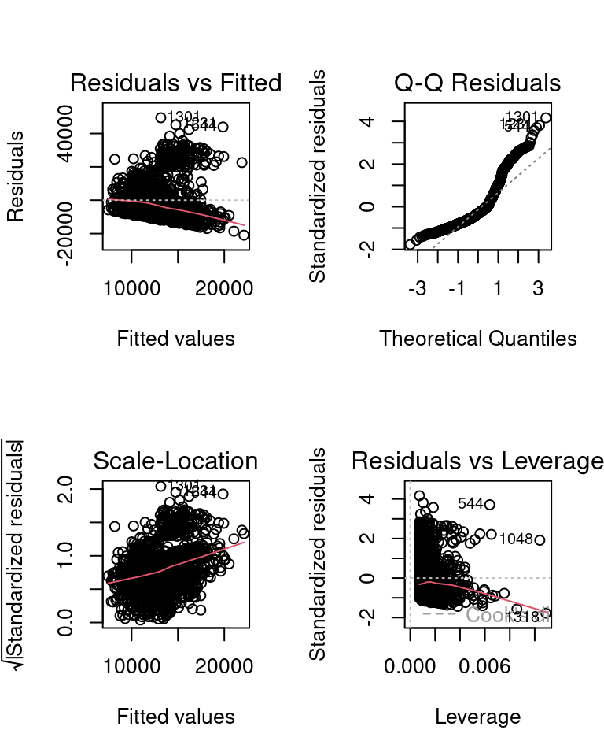

```r
parametric.model <- lm(cost ~ bmi)
par(mfrow = c(2,2))
plot(parametric.model)
```

The above scatter plot indicates a positive linear association between the BMI and the medical insurance cost billed to the beneficiary.

The violations to the model assumptions:

The top-left residual plot has multiple clusters indicating that some group variable is missing. The top-right plot reveals the violation of the normality assumption. The bottom-left plot also reveals the same pattern. The bottom-right plot indicates that there are no serious outliers.

# 5 Inferential Statistics

```r
reg.table <- coef(summary(parametric.model))
pander(reg.table, caption = "Inferential statistics for the parametric linear
      regression model: Medical Insurance Cost and BMI")
```

Inferential statistics for the parametric linear regression model: Medical Insurance Cost and BMI

|  | Estimate | Std. Error | t value | Pr(>\|t\|) |
| --- | --- | --- | --- | --- |
| **(Intercept)** | 1193 | 1665 | 0.7166 | 0.4738 |
| **bmi** | 393.9 | 53.25 | 7.397 | 2.459e-13 |

```r
#Using the bootstrap algorithm on the previous final linear regression model to estimate the bootstrap confidence intervals of regression coefficients (using 95% confidence level).
```

# 6 Bootstrap Regression

```r
vec.id <- 1:length(cost)   # vector of observation ID
boot.id <- sample(vec.id, length(cost), replace = TRUE)   # bootstrap obs ID.
boot.cost <- cost[boot.id]           # bootstrap price
boot.bmi <- bmi[boot.id]     # corresponding bootstrap bmi



B <- 1000    # number of bootstrap replicates
# define empty vectors to store bootstrap regression coefficients
boot.beta0 <- NULL
boot.beta1 <- NULL
## bootstrap regression models using for-loop
vec.id <- 1:length(cost)   # vector of observation ID
for(i in 1:B){
  boot.id <- sample(vec.id, length(cost), replace = TRUE)   # bootstrap obs ID.
  boot.cost <- cost[boot.id]           # bootstrap price
  boot.bmi <- bmi[boot.id]     # corresponding bootstrap distance
  ## regression
  boot.reg <-lm(cost[boot.id] ~ bmi[boot.id])
  boot.beta0[i] <- coef(boot.reg)[1]   # bootstrap intercept
  boot.beta1[i] <- coef(boot.reg)[2]   # bootstrap slope
}

##  95% bootstrap confidence intervals
boot.beta0.ci <- quantile(boot.beta0, c(0.025, 0.975), type = 2)
boot.beta1.ci <- quantile(boot.beta1, c(0.025, 0.975), type = 2)
boot.coef <- data.frame(rbind(boot.beta0.ci, boot.beta1.ci))
names(boot.coef) <- c("2.5%", "97.5%")
pander(boot.coef, caption="Bootstrap confidence intervals of regression coefficients.")
```

Bootstrap confidence intervals of regression coefficients.

|  | 2.5% | 97.5% |
| --- | --- | --- |
| **boot.beta0.ci** | -1985 | 4455 |
| **boot.beta1.ci** | 278.9 | 508 |

# 7 Concluding Remarks

For reporting the inferential result of the BMI coefficient, I recommend to use the bootstrap confidence interval rather than the parametric p-value. The bootstrap confidence interval is robust to potential violations of regression assumptions, as we saw with the residual plots as some assumptions were violated.